# Comparison of Two Data Sets

```r
# Packages ---------------------------------------------------------------
library(equivalence)
library(dplyr)
library(readxl)
library(tidyr)
library(ggplot2)
```

```r
#Identify incoming data:
data.in <- read_excel("W:/Quality Management System/Validation and Verification of methods/Chemistry/Project 203 - Investigation of the PV Room Lighting/PVAL01 comparisons.xlsx",
    skip = 2)
data.in$A <- data.in$`without light`
data.in$B <- data.in$`with light`
An <- "Without_Light"
Bn <- "With_Light"
```

```r
#Clean up data to remove non-numberics:
data.in$A <- sapply(data.in$A, as.numeric)
data.in$B <- sapply(data.in$B, as.numeric)
data.in <- na.omit(data.in)
data.in$row_no <- as.numeric(rownames(data.in))
```

### Data Spread

Plot histogram of the original data set, to see data spread:

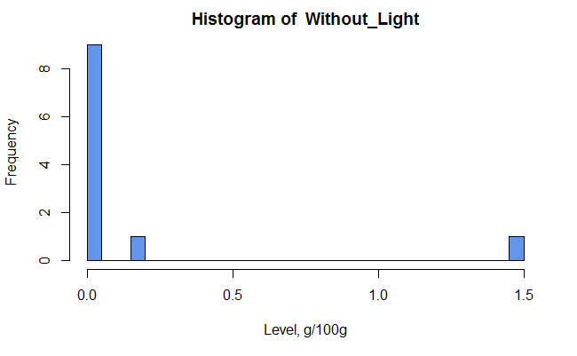

```r
hist(data.in$A,
     main = paste("Histogram of ",An),
     breaks = 30,
     col = "cornflowerblue",
     xlab = "Level, g/100g")
```

Filter the data to remove outlying data and create the difference value. Two high results but leave them in for the moment.

```r
data.in2 <- data.in %>%
        filter(A < 0.5) %>%
        mutate(Diff = B-A)
```

Plot the difference between the new and old methods:

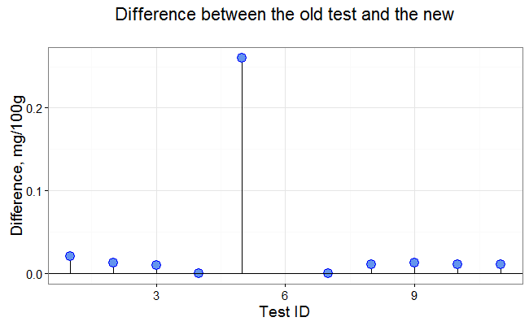

```r
# Plot difference --------------------------------------------------------
ave_diff <- mean(abs(data.in2$Diff))
diff_plot <- ggplot(data.in2, aes(x=row_no, y = Diff)) +
        geom_segment(aes(xend = row_no), yend = 0)+
        geom_point(size = 4, shape = 21, col = "blue", fill = "cornflowerblue") +
        geom_hline(yintercept = 0)+
        theme_bw() +
        theme(axis.line = element_line(size = 0.7, color = "black"),
              text = element_text(size = 14)) +
        labs(x="Test ID", y="Difference, mg/100g",  title= "Difference between the old test and the new\n")
diff_plot
```

Remove any outliers before proceding. In the above plot, point 5 is suspect.

```r
data.in2 <- data.in2 %>%
        filter(Diff <0.1)
```

Least squares fit

```r
fit <- lm(data.in2$B~data.in2$A)
summary(fit)
```

```
Call:
lm(formula = data.in2$B ~ data.in2$A)

Residuals:
       Min         1Q     Median         3Q        Max
-0.0097269  0.0002731  0.0016925  0.0025570  0.0088537

Coefficients:
            Estimate Std. Error t value Pr(>|t|)
(Intercept) 0.005469   0.007693   0.711  0.50018
data.in2$A  1.141939   0.279273   4.089  0.00464 **
---
Signif. codes:  0 â***â 0.001 â**â 0.01 â*â 0.05 â.â 0.1 â â 1

Residual standard error: 0.006467 on 7 degrees of freedom
Multiple R-squared:  0.7049,    Adjusted R-squared:  0.6627
F-statistic: 16.72 on 1 and 7 DF,  p-value: 0.004637
```

```r
confint(fit)
```

```
                  2.5 %     97.5 %
(Intercept) -0.01272327 0.02366069
data.in2$A   0.48156402 1.80231497
```

### Plot Values

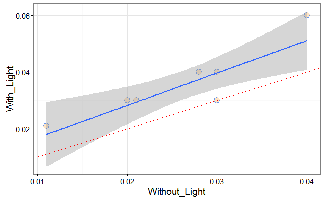

```r
vitc_plot <- ggplot(data.in2, aes(x=A, y=B)) +
        geom_point(size = 4, shape = 21, fill = "bisque", col = "cornflowerblue") +
        geom_smooth(method = lm) +
        geom_abline(slope = 1, intercept = 0, lty = 2, colour = "red") +
        labs(x = An,y = Bn) +
        theme_bw() +
        theme(axis.line = element_line(size = 0.7, color = "black"),
              text = element_text(size = 14))
vitc_plot
```

To further explore the differences, a TOST test is performed.

### Two One-sided t Tests (TOST)

Nominal difference = 0.1

```r
vitc_tost <- tost(data.in2$A, data.in2$B, paired = TRUE, epsilon = 0.1)
vitc_tost
```

```
    Paired TOST

data:  data.in2$A and data.in2$B
df = 8
sample estimates:
mean of the differences
           -0.009222222

Epsilon: 0.1
95 percent two one-sided confidence interval (TOST interval):
 -0.013040436 -0.005404008
Null hypothesis of statistical difference is: rejected
TOST p-value: 3.780838e-11
```

The Ho, that there is a difference between the two data sets is rejected if the epislon, tolerable differnce, is acceptable. That is, there is not enough information to say that they are different.

To get an idea of what differnce in the results would be significant, a series of TOST tests is done and plotted:

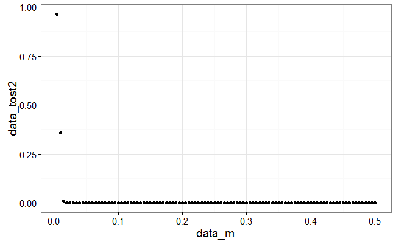

```r
n=0.0
data_tost2 <- rep(0,100)
data_m <- rep(0,100)
for(i in 1:100){
        m = n + i*0.005
        tost_data <- tost(data.in2$A, data.in2$B, paired = TRUE, epsilon = m)
        data_tost2[i] <- tost_data$tost.p.value
        data_m[i] <- m
}
data3 <- as.data.frame(cbind(data_m,data_tost2))
# Plot p values ----------------------------------------------------------
plot_epsilon <- ggplot(data3, aes(x=data_m, y=data_tost2)) +
        geom_point() +
        geom_hline(yintercept = 0.05, col = "red", lty = 2) +
        theme_bw() +
        theme(axis.line = element_line(size = 0.7, color = "black"),
              text = element_text(size = 14))
plot_epsilon
```

```r
limit <- data_07[1,1] + (data_07[2,1]-data_07[1,1]) * (data_07[1,2]-0.05)/(data_07[1,2]-data_07[2,2])
limit
```

```
[1] 0.01444151
```